# Quick Start Guide

First you need to install python. Grab a copy of Anaconda from here: https://www.continuum.io/downloads and install it. Anaconda is a distribution of python that contains a lot of the most used and useful packages. (Anaconda, python.. see what they did there?)  
Next up, you'll need the bottlenose package-  
The easiest way to download this is to type in this command in the command line - *pip install bottlenose*  
If you see an error, then do the following-

Go to https://github.com/lionheart/bottlenose.

On the top right of the table listing out the files, you'll find the "Clone or Download menu", click on it.

In there you'll find an option to download a zip file. Click on it and unzip the file, once the download finishes.

Open a command prompt window and navigate to the unzipped folder and type in *python setup.py install*

Next, from the cmd line go to the directory where you saved this notebook and type in *jupyter notebook* in the command line, to open ju[yter notebook. A browser window will open showing you the current directory tree. click on the file with .ipynb extension.

And that's it. If the command line spits out all sorts of errors at you, shoot me an email at rajkiran.gaddati@assurant.com and I'll be happy to help.

```python
from IPython.core.display import display, HTML
display(HTML("<style>.container { width:95% !important; }</style>"))
from IPython.display import Image
from IPython.core.display import HTML
```

# Getting Amazon Product Data

Amazon has a plethora of valuable data that we can use for various business process optimizations. For example, we can collect product pricing and demand(with supply, Prime and trade-in eligibility as its proxies) data over time to create a pricing model for our refurbished devices. Another use case could be mining the reviews of our competitors' device protection plans and find out what draws customers toward them.

There are two popular ways to mine data from Amazon-

1. Web scraping
2. Use Amazon's Product Advertising API

Web scraping has no official limitations and it is easier to mine reviews through this method. But Amazon is known to alter it's product format frequently which would mean that we'll have to rewrite our code everytime this happens. The use of iframes too makes this process harder. And lastly Amazon is know to ban ips for life(permaban), if caught.

The Product api on the other hand is easy to implement and there is a lot of support for it both from Amazon and the open source community. The limitations here are that Amazon limits the queries per hour to 2000 with an unknown per minute query rate limit. Since the purpose of this API is to drive customers to the Amazon website, the limit will be increased by 200 per hour for each dollar of sales made through our API key.

### Amazon Product Advertising API

**Getting the API**

After signing up, you'll be directed to a page as shown in the screen shot below-

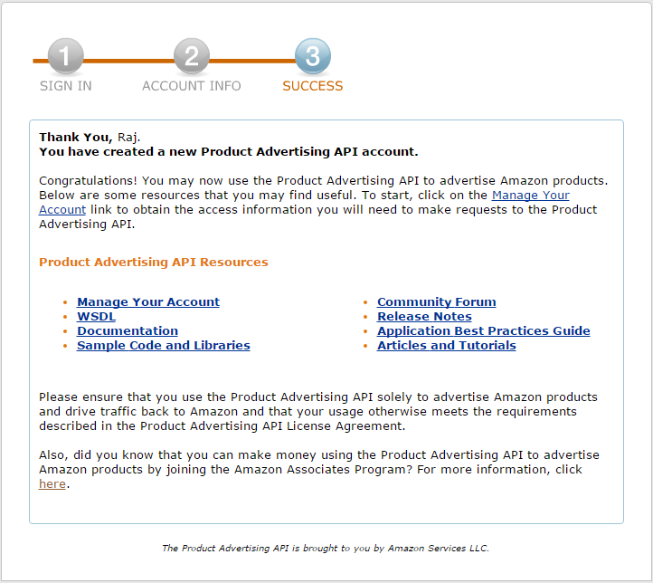

```python
Image('./Registration.PNG')
```

Click on the Amazon Associates Program link at the bottom of the page.

[figure not shown]

```python
Image('./Associates.PNG')
```

Click on the "join now for free" link on the banner at the top of the page. You'll be taken to another registration page.

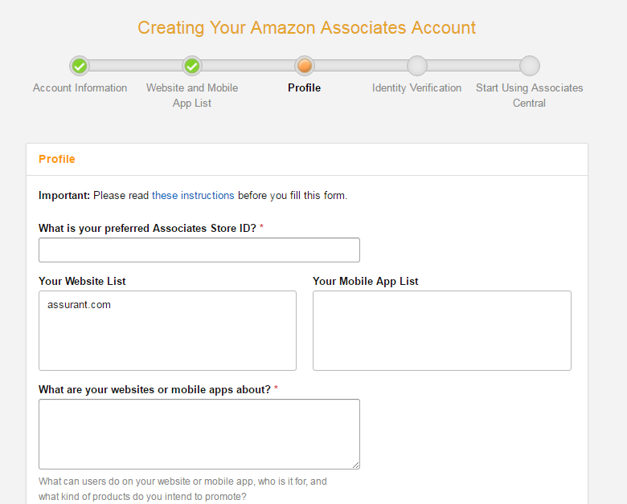

```python
Image('./AssoReg.PNG')
```

On the 3rd page, enter an associate ID for your application in the first field. You'll need to verify your mobile number on the next page. The other fields, though mandatory, are not important for approval by Amazon.

Once this is finished, go to https://console.aws.amazon.com/iam for your API key details.

Under Security Status, click on "Delete Your Root Access Keys" and then "Manage Security Credentials".

On the next page, under "Access Keys (Access Key ID and Secret Access Key)" create a new Access key. You'll find your Access ID and your secret key on the dialog box that appears. Note these down. These along with the Associate ID are needed for authenticating our page requests.

**Bottlenose**

There are many implementations of wrappers for the Amazon API for Python. Bottlenose is one of these and it is highly recommended by its users.

You can find it at https://github.com/lionheart/bottlenose